# Step [1]: Prepare libraries and data

```python
!pip install arabic-reshaper
```

```python
!pip install tashaphyne
```

```python
!pip install wordcloud
```

```python
!pip install PyArabic
```

```python
!pip install python-bidi
```

```python
!pip install qalsadi
```

```python
pip install tashaphyne
```

## [1.1] Include important libraries

```python
import re
import csv
import pandas as pd
import numpy as np
import matplotlib.pyplot as plt
import seaborn as sns
import string
import nltk
import collections
import matplotlib
import qalsadi.lemmatizer
import pyarabic
import pyarabic.araby as araby
import tashaphyne.arabic_const as arabconst
from nltk.collocations import BigramCollocationFinder
from nltk.metrics import BigramAssocMeasures
from nltk.corpus import stopwords
from nltk.tokenize import TweetTokenizer
from nltk import word_tokenize
from nltk.corpus import stopwords
from collections import Counter
from wordcloud import WordCloud
from bidi.algorithm import get_display
from arabic_reshaper import reshape
from tashaphyne.stemming import ArabicLightStemmer
```

```python
nltk.download('stopwords')
```

## [1.2] Download data

```python
!wget 'https://drive.google.com/uc?export=download&id=1KepfzAhJ7dloG8XaWQf0ovQipDHYS8aI' -O 'final_data.zip'
```

```python
!unzip final_data.zip
```

## [1.3] read data from csv files

```python
train_data = pd.read_csv('train.csv')
valid_data = pd.read_csv('valid.csv')
test_data  = pd.read_csv('test.csv')
train_data.head()
```

|  | tweet | label |
| --- | --- | --- |
| 0 | #تبني_قطط_انقاذ من الخاص هاااام كيتن أنثى عمره... | 2 |
| 1 | '#خذ_الخطوة_خذ_اللقاح \nالحمدالله من قبل ومن ب... | 1 |
| 2 | لو اللي مثلك وشرواك طعمو كان قد حذفنا الكمامات... | 1 |
| 3 | #الصحة:•نحو 14.5 مليون شخص تم إعطاؤهم جرعة لقا... | 1 |
| 4 | • في منظور القوة البشرية ( الأزمة ستطول لأشهر ... | 3 |

```python
# Checking null values
train_data[train_data.isnull().any(axis=1)]
```

|  | tweet | label |
| --- | --- | --- |
| 4597 | NaN | 2 |

```python
train_data.drop(4597, inplace=True)
```

# [2] Text Analysis

## [2-1] Count Tweets Per Class:

```python
train_data.label.value_counts()
```

```
3    7338
1    5334
2    3901
0    2783
Name: label, dtype: int64
```

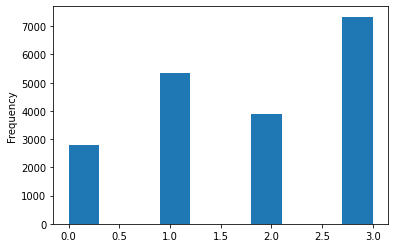

```python
train_data['label'].plot(kind='hist')
```

## [2-2] Find The Most and Least common words in all tweets:

```python
all_tweet = " ".join(train_data['tweet'].tolist())
tokenizer = TweetTokenizer()
tokens = tokenizer.tokenize(all_tweet)
counts_all = collections.Counter(tokens)
#The most common words
counts_all.most_common(10)
counts_all_df = pd.DataFrame(counts_all.most_common(10), columns=['words', 'count'])
counts_all_df.head(10)
```

|  | words | count |
| --- | --- | --- |
| 0 | من | 10731 |
| 1 | لقاح | 9711 |
| 2 | كورونا | 9084 |
| 3 | في | 7616 |
| 4 | . | 5979 |
| 5 | ، | 5701 |
| 6 | على | 4975 |
| 7 | اللقاح | 4308 |
| 8 | " | 4053 |
| 9 | .. | 3530 |

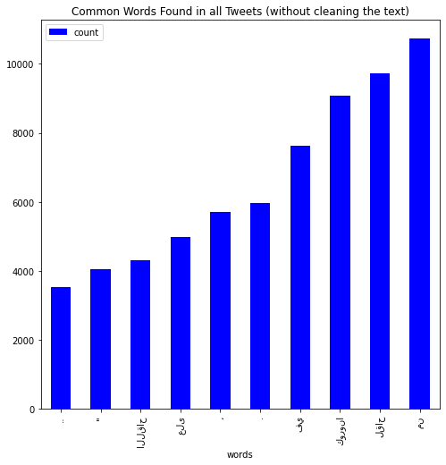

```python
fig, ax = plt.subplots(figsize=(8, 8))

counts_all_df.sort_values(by='count').plot(x='words',y='count',ax=ax,color="blue",kind='bar')

ax.set_title("Common Words Found in all Tweets (without cleaning the text)")

plt.show()
```

نقوم بها قبل معالجة التغريدات وتنظيفها لمعرفة وفهم محتوى التغريدات مما يسهل معرفة مانحن بحاجة لتنظيفه وتسريع عملية التصنيف

```python
c = counts_all.most_common()[-10:]
#The least common words
least_all_df = pd.DataFrame(c, columns=['words', 'count'])
print("the least 5 common word in the uncleaned text:\n")
least_all_df.head(5)
```

```
the least 5 common word in the uncleaned text:
```

|  | words | count |
| --- | --- | --- |
| 0 | https://t.co/uvRlfbQbdX | 1 |
| 1 | #زواج_وليد_الشمري | 1 |
| 2 | #ناقصك_ايه_وتبقي_مبسوط | 1 |
| 3 | #بالزمن_تعلمت | 1 |
| 4 | #البحرين_الكويت | 1 |

WordCloud visualization

```python
def visualization_data(data):
  rtl = lambda w: get_display(reshape(f'{w}'))
  class_text= " ".join(data.tolist())
  COUNTS = Counter(class_text.split())
  counts = {rtl(k):v for k, v in COUNTS.most_common(100)}
  font_file = 'NotoNaskhArabic-Regular.ttf'
  wordcloud = WordCloud(font_path=font_file, width=800, height=500, random_state=21, max_font_size=110).generate_from_frequencies(counts)
  plt.figure(figsize=(10, 7))
  plt.imshow(wordcloud, interpolation="bilinear")
  plt.axis("off")
  plt.title('The most freq words in tweets:')
  plt.show()
```

WordCloud for visualization all tweets

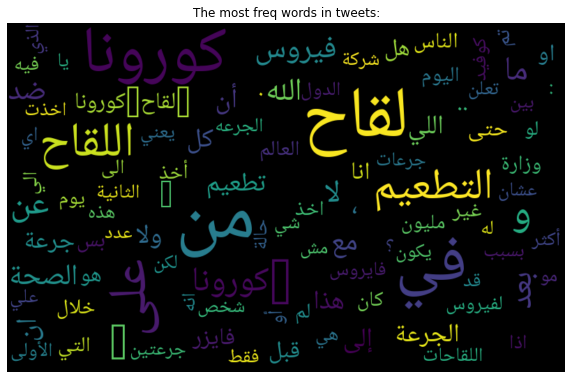

```python
visualization_data(train_data['tweet'])
```

WordCloud for visualization tweets per class '0'

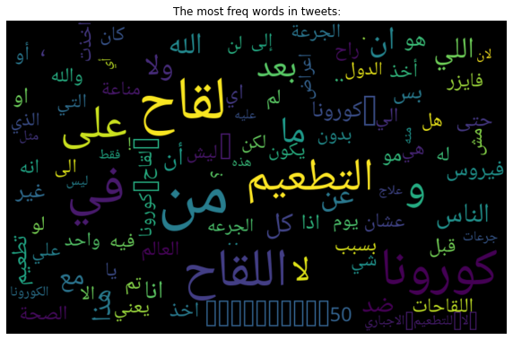

```python
visualization_data((train_data[train_data['label'] == 0]['tweet']))
```

WordCloud for visualization tweets per class '1'

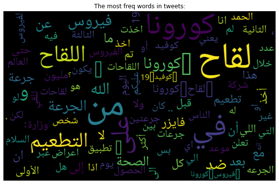

```python
visualization_data((train_data[train_data['label'] == 1]['tweet']))
```

WordCloud for visualization tweets per class '2'

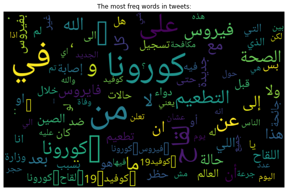

```python
visualization_data((train_data[train_data['label'] == 2]['tweet']))
```

WordCloud for visualization tweets per class '3'

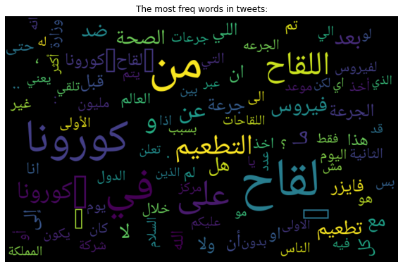

```python
visualization_data((train_data[train_data['label'] == 3]['tweet']))
```

## [2-2] Find the Highest and Lowest Frequency ( n_gram)

```python
def find_ngrams(data):
  class_text = " ".join(data.tolist())
  tokens= tokenizer.tokenize(class_text)
  #unigram
  print('uni_gram -> HighFreq:')
  unigram_freq = nltk.ngrams(tokens, 1)
  unigram_freq=nltk.FreqDist(unigram_freq)
  print(unigram_freq.most_common()[:10])
  print('uni_gram -> LowFreq:')
  print(unigram_freq.most_common()[-10:])
  print('\n')

  #bigram
  print('bi_gram -> HighFreq:')
  bigram_freq = nltk.ngrams(tokens, 2)
  bigram_freq=nltk.FreqDist(bigram_freq)
  print(bigram_freq.most_common()[:10])
  print('bi_gram -> LowFreq:')
  print(bigram_freq.most_common()[-10:])
  print('\n')

  #trigram
  print('tri_gram -> HighFreq:')
  trigram_freq = nltk.ngrams(tokens, 3)
  trigram_freq=nltk.FreqDist(trigram_freq)
  print(trigram_freq.most_common()[:10])
  print('tri_gram -> LowFreq:')
  print(trigram_freq.most_common()[-10:])
```

Find the Highest and Lowest Words Frequency by n_gram in all Classes:

```python
find_ngrams(train_data['tweet'])
```

```
uni_gram -> HighFreq:
[(('من',), 10731), (('لقاح',), 9711), (('كورونا',), 9084), (('في',), 7616), (('.',), 5979), (('،',), 5701), (('على',), 4975), (('اللقاح',), 4308), (('"',), 4053), (('..',), 3530)]
uni_gram -> LowFreq:
[(('https://t.co/uvRlfbQbdX',), 1), (('#زواج_وليد_الشمري',), 1), (('#ناقصك_ايه_وتبقي_مبسوط',), 1), (('#بالزمن_تعلمت',), 1), (('#البحرين_الكويت',), 1), (('#جوز_الست_ياسمين_المحروقه',), 1), (('#حماقي',), 1), (('#عمان_السعودية_مستقبل_مشرق',), 1), (('النظرة',), 1), (('https://t.co/KvdfIk0t1I',), 1)]


bi_gram -> HighFreq:
[(('لقاح', 'كورونا'), 3540), (('من', 'لقاح'), 1248), (('فيروس', 'كورونا'), 1158), (('!', '!'), 775), (('ً', 'ا'), 696), (('\\', 'n'), 649), (('-', '19'), 638), (('كوفيد', '-'), 608), (('لقاح', '#كورونا'), 530), (('?', '?'), 525)]
bi_gram -> LowFreq:
[(('النظرة', 'الشرعية'), 1), (('الشرعية', '😂'), 1), (('😂', 'عندهم'), 1), (('عندهم', '...'), 1), (('...', 'https://t.co/KvdfIk0t1I'), 1), (('https://t.co/KvdfIk0t1I', '@bint__althani'), 1), (('@bint__althani', 'وزير'), 1), (('البريطاني', 'فيروس'), 1), (('جديد', 'ينتشر'), 1), (('غرار', 'فيروس'), 1)]


tri_gram -> HighFreq:
[(('من', 'لقاح', 'كورونا'), 561), (('كوفيد', '-', '19'), 545), (('لقاح', 'فيروس', 'كورونا'), 354), (('ضد', 'فيروس', 'كورونا'), 256), (('\\', 'n', '\\'), 236), (('!', '!', '!'), 214), (('جرعة', 'من', 'لقاح'), 211), (('على', 'لقاح', 'كورونا'), 194), (('الجرعة', 'الثانية', 'من'), 171), (('?', '?', '?')…
tri_gram -> LowFreq:
[(('البريطاني', 'فيروس', 'جديد'), 1), (('فيروس', 'جديد', 'ينتشر'), 1), (('جديد', 'ينتشر', 'في'), 1), (('ينتشر', 'في', 'بريطانيا'), 1), (('في', 'بريطانيا', 'على'), 1), (('بريطانيا', 'على', 'غرار'), 1), (('على', 'غرار', 'فيروس'), 1), (('غرار', 'فيروس', 'كورونا'), 1), (('و', 'لا', 'يوجد'), 1), (('يوجد'…
```

```python
biagram_collocation = BigramCollocationFinder.from_words(tokens)
biagram_collocation.nbest(BigramAssocMeasures.likelihood_ratio, 15)
```

```
[('لقاح', 'كورونا'),
 ('\\', 'n'),
 ('فيروس', 'كورونا'),
 ('ً', 'ا'),
 (':/', '/'),
 ('!', '!'),
 ('?', '?'),
 ('-', '19'),
 ('وزارة', 'الصحة'),
 ('كوفيد', '-'),
 ('السلام', 'عليكم'),
 ('الجرعة', 'الثانية'),
 ('😂', '😂'),
 ('🇸', '🇦'),
 ('الصحة', 'العالمية')]
```

## [2-3] Find the Most and Least common words in every class:

Find the Highest and Lowest Words Frequency by n_gram at Class '0':

```python
find_ngrams(train_data[train_data['label'] == 0]['tweet'])
```

```
uni_gram -> HighFreq:
[(('من',), 1784), (('لقاح',), 1365), (('كورونا',), 1153), (('اللقاح',), 1122), (('في',), 1003), (('.',), 841), (('،',), 839), (('التطعيم',), 821), (('على',), 772), (('و',), 742)]
uni_gram -> LowFreq:
[(('امثالي',), 1), (('افسدوها',), 1), (('بسمومهم',), 1), (('انصرنا',), 1), (('القوم',), 1), (('الطغاه',), 1), (('الكفره',), 1), (('أنام',), 1), (('وطول',), 1), (('بالتخت',), 1)]


bi_gram -> HighFreq:
[(('لقاح', 'كورونا'), 466), (('!', '!'), 214), (('من', 'لقاح'), 102), (('؟', '؟'), 97), (('فيروس', 'كورونا'), 89), (('ً', 'ا'), 79), (('؟', '!'), 74), (('😂', '😂'), 67), (('،', '،'), 66), (('?', '?'), 66)]
bi_gram -> LowFreq:
[(('بحب', 'أنام'), 1), (('أنام', 'وطول'), 1), (('وطول', 'يومي'), 1), (('يومي', 'بالتخت'), 1), (('بالتخت', '🙂'), 1), (('🙂', '🤦'), 1), (('️', '💔'), 1), (('..', 'حسبي'), 1), (('عليهم', 'ونعم'), 1), (('الوكيل', '...'), 1)]


tri_gram -> HighFreq:
[(('!', '!', '!'), 57), (('من', 'لقاح', 'كورونا'), 57), (('كوفيد', '-', '19'), 30), (('\\', 'n', '\\'), 28), (('😂', '😂', '😂'), 26), (('ضد', 'فيروس', 'كورونا'), 26), (('لقاح', 'فيروس', 'كورونا'), 26), (('؟', '؟', '؟'), 25), (('الله', 'ونعم', 'الوكيل'), 21), (('?', '?', '?'), 21)]
tri_gram -> LowFreq:
[(('يومي', 'بالتخت', '🙂'), 1), (('بالتخت', '🙂', '🤦'), 1), (('🙂', '🤦', '🏻'), 1), (('♀', '️', '💔'), 1), (('️', '💔', '..'), 1), (('💔', '..', 'حسبي'), 1), (('..', 'حسبي', 'الله'), 1), (('الله', 'عليهم', 'ونعم'), 1), (('عليهم', 'ونعم', 'الوكيل'), 1), (('ونعم', 'الوكيل', '...'), 1)]
```

Find the Highest and Lowest Words Frequency by n_gram at Class '1':

```python
find_ngrams(train_data[train_data['label'] == 1]['tweet'])
```

```
uni_gram -> HighFreq:
[(('من',), 3309), (('لقاح',), 3242), (('كورونا',), 2569), (('في',), 2247), (('.',), 1899), (('،',), 1825), (('على',), 1614), (('اللقاح',), 1384), (('"',), 1186), (('التطعيم',), 1066)]
uni_gram -> LowFreq:
[(('لمقرب',), 1), (('رافعا',), 1), (('بعلامة',), 1), (('بوضع',), 1), (('إشارة',), 1), (('@UNICEFinArabic',), 1), (('وصديق',), 1), (('تحظى',), 1), (('بإعادة',), 1), (('#vaccinated',), 1)]


bi_gram -> HighFreq:
[(('لقاح', 'كورونا'), 1133), (('من', 'لقاح'), 569), (('فيروس', 'كورونا'), 400), (('\\', 'n'), 325), (('ً', 'ا'), 277), (('-', '19'), 256), (('كوفيد', '-'), 246), (('لقاح', 'فيروس'), 197), (('لقاح', '#كورونا'), 194), (('وزارة', 'الصحة'), 180)]
bi_gram -> LowFreq:
[(('وصديق', 'تلقى'), 1), (('19', 'أيضا'), 1), (('ً', 'وقد'), 1), (('وقد', 'تحظى'), 1), (('تحظى', 'بإعادة'), 1), (('بإعادة', 'المشاركة'), 1), (('المشاركة', '!'), 1), (('!', '✌'), 1), (('✌', 'لحملة'), 1), (('لحملة', '#vaccinated'), 1)]


tri_gram -> HighFreq:
[(('من', 'لقاح', 'كورونا'), 254), (('كوفيد', '-', '19'), 224), (('لقاح', 'فيروس', 'كورونا'), 150), (('\\', 'n', '\\'), 119), (('ضد', 'فيروس', 'كورونا'), 115), (('الجرعة', 'الأولى', 'من'), 112), (('الأولى', 'من', 'لقاح'), 101), (('الجرعة', 'الثانية', 'من'), 85), (('جرعة', 'من', 'لقاح'), 81), (('لقاح'…
tri_gram -> LowFreq:
[(('-', '19', 'أيضا'), 1), (('19', 'أيضا', 'ً'), 1), (('أيضا', 'ً', 'وقد'), 1), (('ً', 'وقد', 'تحظى'), 1), (('وقد', 'تحظى', 'بإعادة'), 1), (('تحظى', 'بإعادة', 'المشاركة'), 1), (('بإعادة', 'المشاركة', '!'), 1), (('المشاركة', '!', '✌'), 1), (('!', '✌', 'لحملة'), 1), (('✌', 'لحملة', '#vaccinated'), 1)]
```

Find the Highest and Lowest Words Frequency by n_gram at Class '2':

```python
find_ngrams(train_data[train_data['label'] == 2]['tweet'])
```

```
uni_gram -> HighFreq:
[(('من',), 1750), (('كورونا',), 1717), (('في',), 1584), (('.',), 1185), (('،',), 1165), (('على',), 793), (('لقاح',), 780), (('..',), 695), (('"',), 693), (('-',), 597)]
uni_gram -> LowFreq:
[(('#ناقصك_ايه_وتبقي_مبسوط',), 1), (('#بالزمن_تعلمت',), 1), (('#البحرين_الكويت',), 1), (('#جوز_الست_ياسمين_المحروقه',), 1), (('#حماقي',), 1), (('#عمان_السعودية_مستقبل_مشرق',), 1), (('النظرة',), 1), (('https://t.co/KvdfIk0t1I',), 1), (('@bint__althani',), 1), (('غرار',), 1)]


bi_gram -> HighFreq:
[(('لقاح', 'كورونا'), 261), (('فيروس', 'كورونا'), 239), (('?', '?'), 232), (('!', '!'), 145), (('بفيروس', 'كورونا'), 128), (('كوفيد', '-'), 115), (('-', '19'), 114), (('فايروس', 'كورونا'), 101), (('وزارة', 'الصحة'), 100), (('ً', 'ا'), 96)]
bi_gram -> LowFreq:
[(('عندهم', '...'), 1), (('...', 'https://t.co/KvdfIk0t1I'), 1), (('https://t.co/KvdfIk0t1I', '@bint__althani'), 1), (('@bint__althani', 'وزير'), 1), (('الصحة', 'البريطاني'), 1), (('البريطاني', 'فيروس'), 1), (('جديد', 'ينتشر'), 1), (('بريطانيا', 'على'), 1), (('على', 'غرار'), 1), (('غرار', 'فيروس'), …


tri_gram -> HighFreq:
[(('كوفيد', '-', '19'), 100), (('?', '?', '?'), 81), (('(', 'كوفيد', '-'), 45), (('جديدة', 'بفيروس', 'كورونا'), 45), (('\u200d', '♀', '️'), 38), (('!', '!', '!'), 37), (('كورونا', '(', 'كوفيد'), 37), (('-', '19', ')'), 36), (('من', 'فيروس', 'كورونا'), 36), (('️', '⃣', '~'), 36)]
tri_gram -> LowFreq:
[(('فيروس', 'جديد', 'ينتشر'), 1), (('جديد', 'ينتشر', 'في'), 1), (('ينتشر', 'في', 'بريطانيا'), 1), (('في', 'بريطانيا', 'على'), 1), (('بريطانيا', 'على', 'غرار'), 1), (('على', 'غرار', 'فيروس'), 1), (('غرار', 'فيروس', 'كورونا'), 1), (('و', 'لا', 'يوجد'), 1), (('لا', 'يوجد', 'لقاح'), 1), (('يوجد', 'لقاح'…
```

Find the Highest and Lowest Words Frequency by n_gram at Class '3':

```python
find_ngrams(train_data[train_data['label'] == 3]['tweet'])
```

```
uni_gram -> HighFreq:
[(('لقاح',), 4324), (('من',), 3888), (('كورونا',), 3645), (('في',), 2782), (('.',), 2053), (('،',), 1872), (('على',), 1796), (('"',), 1753), (('اللقاح',), 1599), (('؟',), 1426)]
uni_gram -> LowFreq:
[(('https://t.co/OKixzdM8WC',), 1), (('تكسر',), 1), (('87115',), 1), (('وزارء',), 1), (('مودي',), 1), (('صديقك',), 1), (('نتياهو',), 1), (('اسهمها',), 1), (('https://t.co/BATj5oQvWY',), 1), (('https://t.co/uvRlfbQbdX',), 1)]


bi_gram -> HighFreq:
[(('لقاح', 'كورونا'), 1680), (('من', 'لقاح'), 533), (('فيروس', 'كورونا'), 430), (('!', '!'), 278), (('لقاح', '#كورونا'), 261), (('على', 'لقاح'), 249), (('ً', 'ا'), 244), (('*', '*'), 237), (('؟', '؟'), 227), (('-', '19'), 225)]
bi_gram -> LowFreq:
[(('اسهمها', '#جنوب_أفريقيا'), 1), (('#جنوب_أفريقيا', 'تبيع'), 1), (('تبيع', 'لقاح'), 1), (('«', '#استرازينيكا'), 1), (('#استرازينيكا', '»'), 1), (('دول', 'أفريقية'), 1), (('أفريقية', 'أخرى'), 1), (('أخرى', 'https://t.co/BATj5oQvWY'), 1), (('https://t.co/BATj5oQvWY', 'https://t.co/uvRlfbQbdX'), 1), …


tri_gram -> HighFreq:
[(('من', 'لقاح', 'كورونا'), 227), (('كوفيد', '-', '19'), 191), (('لقاح', 'فيروس', 'كورونا'), 162), (('جرعة', 'من', 'لقاح'), 117), (('على', 'لقاح', 'كورونا'), 111), (('ضد', 'فيروس', 'كورونا'), 97), (('لقاح', 'كورونا', 'في'), 94), (('!', '!', '!'), 83), (('لقاح', 'كورونا', '؟'), 75), (('منظمة', 'الصحة…
tri_gram -> LowFreq:
[(('«', '#استرازينيكا', '»'), 1), (('#استرازينيكا', '»', 'المضاد'), 1), (('لفيروس', '#كورونا', 'إلى'), 1), (('#كورونا', 'إلى', 'دول'), 1), (('إلى', 'دول', 'أفريقية'), 1), (('دول', 'أفريقية', 'أخرى'), 1), (('أفريقية', 'أخرى', 'https://t.co/BATj5oQvWY'), 1), (('أخرى', 'https://t.co/BATj5oQvWY', 'https…
```

## [2-4] Histogram for tweets length:

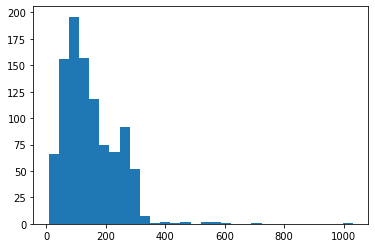

```python
lengths = []
for tweet in train_data['tweet'].head(1000):
    x = len(tweet)
    lengths.append(x)
plt.hist(lengths, bins = 30)
plt.show()
```

## [2-5] Finding the most trending hashtags in all tweets:

```python
hashtags = []
def hashtag_extract(data):
    for i in data:
        ht = re.findall(r"#(\w+)", i)
        hashtags.append(ht)
    return hashtags
```

```python
def hashtag_visualize(data):
  dff_all = hashtag_extract(data)
  dff_all = sum(dff_all,[])
  dff_all = nltk.FreqDist(dff_all)
  dff_all = pd.DataFrame({'Count': list(dff_all.values()),'Hashtag': list(dff_all.keys())}).sort_values(by='Count', ascending=False)
  print(dff_all.head())
  dff_all[:10].plot(x ='Hashtag', y='Count', kind='bar')
```

visualization hashtag for all tweets:

```
    Count       Hashtag
4   23330        كورونا
8    9550   لقاح_كورونا
2    4180  فيروس_كورونا
45   4120      كوفيد_19
12   2710          عاجل
```

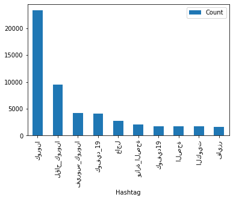

```python
hashtag_visualize(train_data['tweet'])
```

```
    Count       Hashtag
4   23533        كورونا
8    9650   لقاح_كورونا
2    4201  فيروس_كورونا
45   4155      كوفيد_19
12   2730          عاجل
```

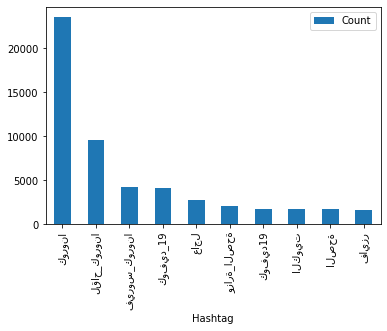

```python
hashtag_visualize(train_data['tweet'][train_data['label'] == 0])
```

```
    Count       Hashtag
4   24244        كورونا
8    9974   لقاح_كورونا
2    4334  فيروس_كورونا
45   4289      كوفيد_19
12   2798          عاجل
```

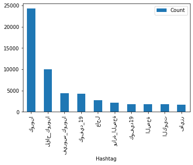

```python
hashtag_visualize(train_data['tweet'][train_data['label'] == 1])
```

```
    Count       Hashtag
4   24725        كورونا
8   10104   لقاح_كورونا
2    4443  فيروس_كورونا
45   4410      كوفيد_19
12   2860          عاجل
```

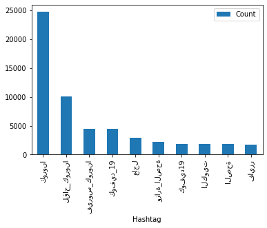

```python
hashtag_visualize(train_data['tweet'][train_data['label'] == 2])
```

```
    Count       Hashtag
4   25663        كورونا
8   10505   لقاح_كورونا
2    4598  فيروس_كورونا
45   4532      كوفيد_19
12   2981          عاجل
```

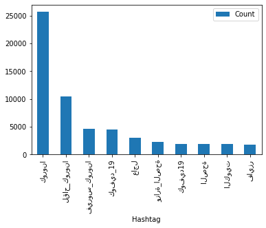

```python
hashtag_visualize(train_data['tweet'][train_data['label'] == 3])
```

## [3] Text cleaning and Normalization

## [3-1] Removing Mintions and Links and Photos from text:

```python
my_test_case = train_data.tweet[79] #A tweet with mintion & link & repeated letters
print(my_test_case)
```

```
@awadoooof انا بفقد عقلي من كثر تلميع ذا اللقاح الي يناسب كل الاجسام والاعمار يياااااهههوماني ماخذ اللقاح https://t.co/8VuAf6vf4W
```

```python
def remove_mintions(tweet,work):
  '''
  تنظيف أسماء المستخدمين
  '''
  if work ==1:
    cleaned_tweet = re.sub(r"@\S+",'',tweet)
  else:
    cleaned_tweet = tweet
  return cleaned_tweet
```

```python
print('A Tweet without clean mintion')
print(train_data.tweet[0]+'\n')

print('A Tweet with clean mintion')
remove_mintions(train_data.tweet[0],1)
```

```
A Tweet without clean mintion
#تبني_قطط_انقاذ من الخاص هاااام كيتن أنثى عمرها ٥٩ يوم اخذتها حديثه الولاده عمرها ٣ ايام تم التطعيم امس سبب العرض للتبني انا اعتني بالقطط حديثه الولاده  وعند اكتمال شهرين يحتاجوا مساحة  وانا ما عندي هادي لوجود اكثر من ٧ قطط حديثه الولاده للتواصل @saad28234346 التبني الرياض

A Tweet with clean mintion
```

```
'#تبني_قطط_انقاذ من الخاص هاااام كيتن أنثى عمرها ٥٩ يوم اخذتها حديثه الولاده عمرها ٣ ايام تم التطعيم امس سبب العرض للتبني انا اعتني بالقطط حديثه الولاده  وعند اكتمال شهرين يحتاجوا مساحة  وانا ما عندي هادي لوجود اكثر من ٧ قطط حديثه الولاده للتواصل  التبني الرياض '
```

```python
def remove_urls(tweet,work):
  '''
  تنظيف الروابط
  '''
  if work ==1:
      cleaned_tweet = re.sub(r"(https|http|ftp)?://\S*.((\S*\S*)|(\S*))",'', tweet)
  else:
    cleaned_tweet = tweet
  return cleaned_tweet
```

```python
'''
There is no duplicate lines
'''
train_data.duplicated().sum()
```

```
0
```

```python
print('A Tweet without clean urls ')
print(train_data.tweet[1]+'\n')
print('A Tweet with clean urls ')
remove_urls(train_data.tweet[1],1)
```

```
A Tweet without clean urls
'#خذ_الخطوة_خذ_اللقاح \nالحمدالله من قبل ومن بعد أخذت اليوم \nالجرعه الأولى من لقاح #فيروس_كورونا\nأسأل الله أن يجعل فيه العافيه وأن يزيل \nعن هذا الوباء عاجلا غير آجل. https://t.co/nG1D24s5Bx'

A Tweet with clean urls
```

```
"'#خذ_الخطوة_خذ_اللقاح \\nالحمدالله من قبل ومن بعد أخذت اليوم \\nالجرعه الأولى من لقاح #فيروس_كورونا\\nأسأل الله أن يجعل فيه العافيه وأن يزيل \\nعن هذا الوباء عاجلا غير آجل. "
```

```python
def remove_images(tweet,work):
  '''
  تنظيف الصور
  '''
  if work ==1:
    cleaned_tweet = re.sub(r"pic\.twitter\.com/\S+",'', tweet)
    cleaned_tweet = re.sub("\w+(\.png|\.jpg|\.gif|\.jpeg)", " ", cleaned_tweet)
  else:
    cleaned_tweet = tweet
  return cleaned_tweet
```

لا نقوم بحذف الهاشتاغات لأنها أكثر مايعبر عن محتوى التغريدة وبالتالي الكلمات التي تتبعها ستساعدنا كثيرا في عملية التصنيف لاحقاً

## (3-2) Removing duplicated characters in words:

```python
def  remove_duplicated_char(tweet,work):
  '''
  تنظيف التغريدات من الأحرف المكررة
  '''
  if work ==1:
    cleaned_tweet= re.sub(r'(\w)\1+', r'\1', tweet)
    cleaned_tweet =re.sub(r'(.)\1+', r'\1',cleaned_tweet)

  else:
    cleaned_tweet = tweet
  return cleaned_tweet
```

```python
print("A Tweet without cleaning duplicated characters :\n")
print(my_test_case + '\n')
print("A Tweet with cleaning duplicated characters :\n")
print( preprocess_tweet(my_test_case))
```

```
A Tweet without cleaning duplicated characters :

@awadoooof انا بفقد عقلي من كثر تلميع ذا اللقاح الي يناسب كل الاجسام والاعمار يياااااهههوماني ماخذ اللقاح https://t.co/8VuAf6vf4W

A Tweet with cleaning duplicated characters :

 انا بفقد عقلي من كثر تلميع ذا القاح الي يناسب كل الاجسام والاعمار ياهوماني ماخذ القاح
```

```python
def  preprocess_tweet(tweet):
    '''
     استدعاء توابع التنظيف السابقة جميعها
    '''
    cleaned_tweet= remove_urls(tweet,1)
    cleaned_tweet= remove_images(cleaned_tweet,1)
    cleaned_tweet= remove_mintions(cleaned_tweet,1)
    cleaned_tweet= remove_duplicated_char(cleaned_tweet,1)
    return cleaned_tweet
```

```python
def preprocesse(df, text_field):
    df['cleaned_tweet'] = df[text_field].apply(lambda x: preprocess_tweet(str(x)))
    return df
```

```python
train_data.drop(['cleaned_text'], axis=1)
```

[output not shown]

19356 rows × 3 columns

```python
def remove_tweet_digits(tweet,work):
    '''
     تنضيف الترقيم
    '''
    if work ==1:
        cleaned_tweet = re.sub(r'[d]+', r'', tweet)
        cleaned_tweet = re.sub(r'([0-9]*\-[0-9]*)*', '', cleaned_tweet)
    else:
        cleaned_tweet = tweet
    return cleaned_tweet
```

```python
print("A Tweet without cleaning digits :\n")
print( train_data.tweet[3]+ '\n')
print("A Tweet with cleaning digist :\n")
print( remove_tweet_digits(train_data.tweet[3],1))
```

```
A Tweet without cleaning digits :

#الصحة:•نحو 14.5 مليون شخص تم إعطاؤهم جرعة لقاح #كورونا•اللقاحات آمنة وبإمكان كل من تلقى اللقاح التبرع بالدم•يمكن تلقي جرعات مختلفة من لقاح كورونا

A Tweet with cleaning digist :

#الصحة:•نحو 14.5 مليون شخص تم إعطاؤهم جرعة لقاح #كورونا•اللقاحات آمنة وبإمكان كل من تلقى اللقاح التبرع بالدم•يمكن تلقي جرعات مختلفة من لقاح كورونا
```

```python
def removing_digits(df, text_field):
  df['cleaned_tweet'] = df[text_field].apply(lambda x: remove_tweet_digits(str(x),1))
  return df
```

من الممكن أن تكون الأرقام مفيدة للدلالة على رقم اللقاح الشائع كما في كلمة (كوفيد-19) أو من معرفة تواريخ تلقي اللقاح كما أنه يفيد في معرفة عدد متلقي اللقاح مما يسهل اجراء تصنيفات اخرى لاحقاُ

## (3-5) Removing Emojies and Punctuation and Stop words:

```python
all_stop_words = set(stopwords.words('arabic'))
```

```python
def remove_stopword(tweet,work):
   """Process tweet function.
    Input:
        tweet: a string containing a tweet without removing Arabic stopword
    Output:
        cleaned_tweet: tweet with removing Arabic stopword
    """
   words= " "
   for t in tweet:
     if t not in all_stop_words:
       words += t + " "

   if work ==1:
    cleaned_tweet = words
   else:
    cleaned_tweet = tweet
   return cleaned_tweet
```

```python
print("A tweet without removing Arabic stopword:\n")
print(my_test_case + '\n')
token =tokenizer.tokenize(str(my_test_case))
print("A tweet witho removing Arabic stopword:\n")
print(remove_stopword(token,1))
```

```
A tweet without removing Arabic stopword:

@awadoooof انا بفقد عقلي من كثر تلميع ذا اللقاح الي يناسب كل الاجسام والاعمار يياااااهههوماني ماخذ اللقاح https://t.co/8VuAf6vf4W

A tweet witho removing Arabic stopword:

 @awadoooof انا بفقد عقلي كثر تلميع اللقاح الي يناسب الاجسام والاعمار يياااهههوماني ماخذ اللقاح https://t.co/8VuAf6vf4W
```

```python
def remove_all_stopwords(df,text_field):
    df['cleaned_tweet'] = df[text_field].apply(lambda x: " ".join([w for w in str(x).split() if not w in all_stop_words]))
    return df
```

```python
def remove_tweet_emojies(tweet,work):

    """Process tweet function.
    Input:
        tweet: a string containing a tweet without removing Emojies
    Output:
        cleaned_tweet: tweet with removing Emojies
    """
    emoji_pattern = re.compile("["
        u"\U0001F600-\U0001F64F"  # emoticons
        u"\U0001F300-\U0001F5FF"  # symbols & pictographs
        u"\U0001F680-\U0001F6FF"  # transport & map symbols
        u"\U0001F1E0-\U0001F1FF"  # flags (iOS)
        u"\U0001F1F2-\U0001F1F4"  # Macau flag
        u"\U0001F1E6-\U0001F1FF"  # flags
        u"\U0001F600-\U0001F64F"
        u"\U00002702-\U000027B0"
        u"\U000024C2-\U0001F251"
        u"\U0001f926-\U0001f937"
        u"\U0001F1F2"
        u"\U0001F1F4"
        u"\U0001F620"
        u"\u200d"
        u"\u2640-\u2642"
        "]+", flags=re.UNICODE)
    if work ==1:
       cleaned_tweet = emoji_pattern.sub(r'',tweet)
    else:
      cleaned_tweet = tweet


    return cleaned_tweet
```

```python
print("A tweet without removing Emojies :\n")
print( train_data.tweet[7]+ '\n')
print("a tweet with removing Emojies :\n")
print(remove_tweet_emojies(train_data.tweet[7],1))
```

```
A tweet without removing Emojies :

🚨السلطات الصحية تعلن تطعيم أكثر من نصف مليون طفل في الفئة العمرية [12-17] بلقاح فيروس كورونا في أنحاء البلاد بعد أقل من أسبوع على بدء تطعيم هذه الفئة https://t.co/XbqFBwGEYI

a tweet with removing Emojies :

السلطات الصحية تعلن تطعيم أكثر من نصف مليون طفل في الفئة العمرية [12-17] بلقاح فيروس كورونا في أنحاء البلاد بعد أقل من أسبوع على بدء تطعيم هذه الفئة https://t.co/XbqFBwGEYI
```

```python
def remove_all_tweet_emojies(df, text_field):
    df['cleaned_tweet'] = df[text_field].apply(lambda x: remove_tweet_emojies(str(x),1))
    return df
```

- وجود الرموز التعبيرية من الممكن أن يفيد في معرفة نوع التغريدة حيث من الممكن أن تكون العبارة حيادية أو ربما هدفها السخرية من اللقاح علما ان الجملة تحوي معنى إيجابي فوجود الرمز التعبيري هو مايعبر عما اذا كانت داعمة لأخذ اللقاح أم لا

```python
remove_all_tweet_emojies(train_data, 'tweet').head(5)
```

```python
def remove_punctuation(tweet,work):
   """Process tweet function.
    Input:
        tweet: a string containing a tweet without removing punctuations
    Output:
        cleaned_tweet: tweet after removing punctuations

    """
   if work ==1:
      cleaned_tweet =re.sub('[%s]' % re.escape("""!"#$%&'()*+,،-./:;<=>؟?@[\]^_`{|}~|\•|\)|\("""), ' ', tweet)
   else:
     cleaned_tweet = tweet
   return cleaned_tweet
```

```python
print("A tweet without removing punctuations:\n")
print( train_data.tweet[4]+ '\n')
print("a tweet with removing punctuations:\n")
print(remove_punctuation(train_data.tweet[4],1))
```

```
A tweet without removing punctuations:

• في منظور القوة البشرية ( الأزمة ستطول لأشهر - كورونا في انتشار - اللقاح يحتاج إلى سنة لاعتماده ) • وفي القدرة الإلهية لطف ورحمة وحكمة قال ربي سبحانه وتعالى: { وما كانَ اللهُ ليُعجزه من شيءٍ في السماوات ولا في الأرض إنه كان عليمًا قديرًا }

a tweet with removing punctuations:

  في منظور القوة البشرية   الأزمة ستطول لأشهر   كورونا في انتشار   اللقاح يحتاج إلى سنة لاعتماده     وفي القدرة الإلهية لطف ورحمة وحكمة قال ربي سبحانه وتعالى    وما كانَ اللهُ ليُعجزه من شيءٍ في السماوات ولا في الأرض إنه كان عليمًا قديرًا
```

## (3-6) Removing characters and English words:

```python
#remove not arabic word from tweet
def remove_NotArabic_chars(tweet,work):
    """
    Process tweet function.
    Input:
        tweet: a string containing a tweet without changing
    Output:
        cleaned_tweet:A tweet after  remove_NotArabic_chars
    """
    if work ==1:
      cleaned_tweet = re.sub(r'[/(){}\[\]\|]', '', tweet)
      cleaned_tweet = re.sub(r'[!$%^?&*><]', '', cleaned_tweet )
      cleaned_tweet = re.sub(r'[\'\"،—.,;+-=]', '', cleaned_tweet )
      cleaned_tweet = re.sub(r'[\n]', '', cleaned_tweet ) # removing \n
      cleaned_tweet = re.sub(r'\s*[A-Za-z]+\b', '' ,cleaned_tweet )# removing English letters
      cleaned_tweet =re.sub(r"\s+",' ',cleaned_tweet) # remove_extra_white_space
    else:
     cleaned_tweet = tweet
    return cleaned_tweet
```

```python
print("A tweet before remove NotArabic chars:\n")
print( train_data.tweet[100]+ '\n')
print("A tweet fter remove NotArabic chars tweet:\n")
print(remove_NotArabic_chars(train_data.tweet[100],1))
```

```
A tweet before remove NotArabic chars:

#مورجان_ستانلى يتولى جمع 1.3 مليار دولار لـ«#مودرنا» لـ #تمويل #لقاح_كورونا  https://t.co/9OSi3vXOJk #اسهم #ادوية #شركات https://t.co/QDatIyMksf

A tweet fter remove NotArabic chars tweet:

#مورجان_ستانلى يتولى جمع مليار دولار لـ«#مودرنا» لـ #تمويل #لقاح_كورونا #اسهم #ادوية #شركات
```

```python
def remove_all_NotArabic_chars(df, text_field):
    df['cleaned_tweet'] = df[text_field].apply(lambda x: remove_NotArabic_chars(str(x),1))
    return df
```

```python
remove_all_NotArabic_chars(train_data, 'tweet').head(5)
```

## (3-7) Lemmatization And stemming Arabic Words:

```python
#استخدام مكتبة لايجاد الجذور للكلمات باللغة العربية
from tashaphyne.stemming import ArabicLightStemmer
import pyarabic.arabrepr
```

```python
def tashaphyne_stemming(tweet,work):
  if work == 1:
    tweet_tokens = tokenizer.tokenize(tweet)
    arepr = pyarabic.arabrepr.ArabicRepr()
    repr = arepr.repr
    ArListem = ArabicLightStemmer()
    output = ""

    for word in tweet_tokens:
        if (word.find("#") == -1): # we dont stemm a hashtag
            stem = ArListem.light_stem(word)
            stem = ArListem.get_stem()
            print(word + " -> "+ stem)
        else:
            stem = word
        output+=(stem + " ")

    cleaned_tweet= "".join(output)
  else:
    cleaned_tweet = tweet
  return cleaned_tweet
```

```python
print("Before stemming tweet:\n")
print( train_data.tweet[90]+ '\n')
print("After stemming tweet:\n")
print(tashaphyne_stemming(train_data.tweet[90],1))
```

```
Before stemming tweet:

5 وبينت النتائج من لقاح ميرس عدم وجود فرق كبير بين الجرعات في المتبرعين وعدم قدرتة على استحثاث المناعة في جميع المتبرعين وانه وبالرغم من انتاج اجسام مضاده في البعض الا انها فوقدت مع مرور والوقت او كانت ضعيفة #فيروس #كورونا_المستجد #كوفيد١٩


After stemming tweet:

5 -> 5
وبينت -> ينت
النتائج -> نتائج
من -> من
لقاح -> قاح
ميرس -> ميرس
عدم -> عدم
وجود -> جود
فرق -> رق
كبير -> بير
بين -> بين
الجرعات -> جرع
في -> في
المتبرعين -> متبرع
وعدم -> عدم
قدرتة -> قدرت
على -> على
استحثاث -> استحثاث
المناعة -> مناع
في -> في
جميع -> جميع
المتبرعين -> متبرع
وانه -> نه
وبالرغم -> رغم
من -> من
انتاج -> نتاج
اجسام -> جسام
مضاده -> مضاد
في -> في
البعض -> بعض
الا -> لا
انها -> نه
فوقدت -> وقد
مع -> مع
مرور -> مرور
والوقت -> وقت
او -> او
كانت -> انت
ضعيفة -> ضعيف
5 ينت نتائج من قاح ميرس عدم جود رق بير بين جرع في متبرع عدم قدرت على استحثاث مناع في جميع متبرع نه رغم من نتاج جسام مضاد في بعض لا نه وقد مع مرور وقت او انت ضعيف #فيروس #كورونا_المستجد #كوفيد١٩
```

```python
def clean2(df, text_field):
    df['cleaned_tweet'] = df[text_field].apply(lambda x: tashaphyne_stemming(str(x),1))
    return df
```

```python
clean2(train_data, 'cleaned_tweet').head(5)
```

```python
import qalsadi.lemmatizer
def qalsadi_lemmatizer(tweet,work):
  lemmer = qalsadi.lemmatizer.Lemmatizer()
  tweet_tokens = tokenizer.tokenize(tweet)
  if work == 1:
    output = ""
    for word in tweet_tokens:
      if (word.find("#") == -1):  # we dont lemmatize a hashtag
        lemma = lemmer.lemmatize(word)
        print(word + " -> "+ lemma)
      else:
        lemma = word
      output+=(lemma + " ")
    cleaned_tweet= "".join(output)
  else:
    cleaned_tweet = tweet
  return cleaned_tweet
```

```python
print("Before Lemmatizing tweet:\n")
print( train_data.tweet[90]+ '\n')
print("After Lemmatizing tweet:\n")
print(qalsadi_lemmatizer(train_data.tweet[90],1))
```

```
Before Lemmatizing tweet:

5 وبينت النتائج من لقاح ميرس عدم وجود فرق كبير بين الجرعات في المتبرعين وعدم قدرتة على استحثاث المناعة في جميع المتبرعين وانه وبالرغم من انتاج اجسام مضاده في البعض الا انها فوقدت مع مرور والوقت او كانت ضعيفة #فيروس #كورونا_المستجد #كوفيد١٩


After Lemmatizing tweet:

5 -> 5
وبينت -> بين
النتائج -> نتائج
من -> من
لقاح -> لقاح
ميرس -> ميرس
عدم -> عدم
وجود -> جود
فرق -> فرق
كبير -> كبير
بين -> بين
الجرعات -> جرعة
في -> في
المتبرعين -> متبرع
وعدم -> عدم
قدرتة -> قدرتة
على -> على
استحثاث -> استحثاث
المناعة -> مناع
في -> في
جميع -> جميع
المتبرعين -> متبرع
وانه -> نهو
وبالرغم -> رغم
من -> من
انتاج -> انتاج
اجسام -> اجسام
مضاده -> مضاد
في -> في
البعض -> بعض
الا -> ال
انها -> انها
فوقدت -> وقد
مع -> مع
مرور -> مرور
والوقت -> وقت
او -> او
كانت -> كانت
ضعيفة -> ضعيف
5 بين نتائج من لقاح ميرس عدم جود فرق كبير بين جرعة في متبرع عدم قدرتة على استحثاث مناع في جميع متبرع نهو رغم من انتاج اجسام مضاد في بعض ال انها وقد مع مرور وقت او كانت ضعيف #فيروس #كورونا_المستجد #كوفيد١٩
```

```python
def cleaned3(df, text_field):
    df['lemmatized'] = df[text_field].apply(lambda x: qalsadi_lemmatizer(str(x),1))
    return df
```

```python
cleaned3(train_data, 'tweet').head(5)
```

الهاشتاغات يجب أن لاتجذع ولا تجذر لانه من الممكن كثيرا ان يتغير معنى الكلمة الواردة بعده حيث تحمل المعنى الأكثر أهمية للجملة وذلك واضح من خلال خرج عمليات التجذير السابقة

## (3-8) Characters normalization:

# لمعالجة بعض الاخطاء الاملائية وتقليل عدد كبير من الكلمات المتشابهة ذات نفس المعنى

```python
#  The converted letters are :
#  The converted lettersinto HAMZA are: WAW_HAMZA,YEH_HAMZA
#  The converted lettersinto ALEF are: ALEF_MADDA,
#  ALEF_HAMZA_ABOVE, ALEF_HAMZA_BELOW ,HAMZA_ABOVE, HAMZA_BELOW
def hamza_normalizing(tweet,work):
  if work ==1:
    cleaned_tweet = arabconst.ALEFAT_PAT.sub(arabconst.ALEF, tweet)
    return arabconst.HAMZAT_PAT.sub(arabconst.HAMZA,cleaned_tweet )
  else:
    return tweet
```

```python
print("Before processing tweet:\n")
text="أهؤلاء من أولئكُ"
print( text+ '\n')
print("After processing tweet:\n")
print(hamza_normalizing(text,1))
```

```
Before processing tweet:

أهؤلاء من أولئكُ

After processing tweet:

اهءلاء من اولءكُ
```

```python
#تحويل التاء المربوطة الى هاء والألف المقصورة الى ياء
def spellerrors_normalizing(tweet,work):
  if work ==1:
    cleaned_tweet = re.sub(u'[%s]' % arabconst.TEH_MARBUTA, arabconst.HEH, tweet)
    return re.sub(u'[%s]' % arabconst.ALEF_MAKSURA, arabconst.YEH, cleaned_tweet)
  else:
    return tweet
```

```python
print("Before processing tweet:\n")
print( train_data.tweet[3]+ '\n')
print("After processing tweet:\n")
print(spellerrors_normalizing(train_data.tweet[3],1))
```

```
Before processing tweet:

#الصحة:•نحو 14.5 مليون شخص تم إعطاؤهم جرعة لقاح #كورونا•اللقاحات آمنة وبإمكان كل من تلقى اللقاح التبرع بالدم•يمكن تلقي جرعات مختلفة من لقاح كورونا

After processing tweet:

#الصحه:•نحو 14.5 مليون شخص تم إعطاؤهم جرعه لقاح #كورونا•اللقاحات آمنه وبإمكان كل من تلقي اللقاح التبرع بالدم•يمكن تلقي جرعات مختلفه من لقاح كورونا
```

- من أجل توحيد النصوص بشكل أفضل تم اضافة التوابع التالية لإزالة التطوبل والتشكيل من الكلمات

```python
#إزالة التشكيل من الكلمات
def strip_tashkeel(tweet,work):
  if work ==1:
    return arabconst.HARAKAT_PAT.sub('', tweet)
  else:
    return tweet
```

```python
print("Before processing tweet:\n")
print( train_data.tweet[4]+ '\n')
print("After processing tweet:\n")
print(strip_tashkeel(train_data.tweet[4],1))
```

```
Before processing tweet:

• في منظور القوة البشرية ( الأزمة ستطول لأشهر - كورونا في انتشار - اللقاح يحتاج إلى سنة لاعتماده ) • وفي القدرة الإلهية لطف ورحمة وحكمة قال ربي سبحانه وتعالى: { وما كانَ اللهُ ليُعجزه من شيءٍ في السماوات ولا في الأرض إنه كان عليمًا قديرًا }

After processing tweet:

• في منظور القوة البشرية ( الأزمة ستطول لأشهر - كورونا في انتشار - اللقاح يحتاج إلى سنة لاعتماده ) • وفي القدرة الإلهية لطف ورحمة وحكمة قال ربي سبحانه وتعالى: { وما كان الله ليعجزه من شيء في السماوات ولا في الأرض إنه كان عليما قديرا }
```

```python
#إزالة التطويل من الكلمات
def strip_tatweel(tweet,work):
  if work ==1:
    return re.sub(u'[%s]'% arabconst.TATWEEL,'', tweet)
  else:
    return tweet
```

```python
print("Before processing tweet:\n")
text="العـــــربية"
print(text+ '\n')
print("After processing tweet:\n")
print(strip_tatweel(text,1))
```

```
Before processing tweet:

العـــــربية

After processing tweet:

العربية
```

```python
def Characters_normalization(text):
  text = hamza_normalizing(text,1)
  text = spellerrors_normalizing(text,1)
  text = strip_tashkeel(text,1)
  text = strip_tatweel(text,1)
  return text
```

```python
def clean_chars(df, text_field):
    df['cleaned_tweet'] = df[text_field].apply(lambda x: Characters_normalization(str(x)))
    return df
```

```python
clean_chars(train_data, 'tweet').head(20)
```

|  | tweet | label | cleaned_tweet |
| --- | --- | --- | --- |
| 0 | #تبني_قطط_انقاذ من الخاص هاااام كيتن أنثى عمره... | 2 | #تبني_قطط_انقاذ من الخاص هاااام كيتن انثي عمره... |
| 1 | '#خذ_الخطوة_خذ_اللقاح \nالحمدالله من قبل ومن ب... | 1 | '#خذ_الخطوه_خذ_اللقاح \nالحمدالله من قبل ومن ب... |
| 2 | لو اللي مثلك وشرواك طعمو كان قد حذفنا الكمامات... | 1 | لو اللي مثلك وشرواك طعمو كان قد حذفنا الكمامات... |
| 3 | #الصحة:•نحو 14.5 مليون شخص تم إعطاؤهم جرعة لقا... | 1 | #الصحه:•نحو 14.5 مليون شخص تم اعطاءهم جرعه لقا... |
| 4 | • في منظور القوة البشرية ( الأزمة ستطول لأشهر ... | 3 | • في منظور القوه البشريه ( الازمه ستطول لاشهر ... |
| 5 | دول رفعت شعار لقاح #كورونا مجانا لكافة المواط... | 3 | دول رفعت شعار لقاح #كورونا مجانا لكافه المواط... |
| 6 | @mayahaydarali طيب لية السعودية زي ماكتشفت لقا... | 3 | @mayahaydarali طيب ليه السعوديه زي ماكتشفت لقا... |
| 7 | 🚨السلطات الصحية تعلن تطعيم أكثر من نصف مليون ط... | 3 | 🚨السلطات الصحيه تعلن تطعيم اكثر من نصف مليون ط... |
| 8 | بوتين يحصل مجددًا على لقاح مضاد لفيروس كورونا ... | 1 | بوتين يحصل مجددا علي لقاح مضاد لفيروس كورونا ... |
| 9 | تسعى شركه مودرنا الأمريكيه لاستصدار ترخيص من ه... | 1 | تسعي شركه مودرنا الامريكيه لاستصدار ترخيص من ه... |
| 10 | روضة هباس تبعد عن مركز الشعبة 80 كلم ذ وع. htt... | 2 | روضه هباس تبعد عن مركز الشعبه 80 كلم ذ وع. htt... |
| 11 | https://t.co/ihiyA9JD0O @Riyadh_ibrahimm @DrNa... | 1 | https://t.co/ihiyA9JD0O @Riyadh_ibrahimm @DrNa... |
| 12 | https://t.co/DU73r2P3AK https://t.co/SakaZk4b... | 1 | https://t.co/DU73r2P3AK https://t.co/SakaZk4b... |
| 13 | '#خذ_الخطوة وساهم في تحقيق المناعة المجتمعية ل... | 1 | '#خذ_الخطوه وساهم في تحقيق المناعه المجتمعيه ل... |
| 14 | @Official_Hana01 رحمة الله عليهم دا غير الدك... | 3 | @Official_Hana01 رحمه الله عليهم دا غير الدك... |
| 15 | '14 ابريل \nجرعة لقاح كورونا (اكسفورد)الاولى ✅' | 1 | '14 ابريل \nجرعه لقاح كورونا (اكسفورد)الاولي ✅' |
| 16 | @A1_NajM_1A @iii9bi @KsaBankr انا جاني كورونا ... | 3 | @A1_NajM_1A @iii9bi @KsaBankr انا جاني كورونا ... |
| 17 | @sho99shoA @udfsdf5662 @News_Ejazah ماتشوفون ا... | 0 | @sho99shoA @udfsdf5662 @News_Ejazah ماتشوفون ا... |
| 18 | صباح الخير اللهم حبب إلينا الإيمان وزينه في قل... | 2 | صباح الخير اللهم حبب الينا الايمان وزينه في قل... |
| 19 | https://t.co/Ce6m7unUsM https://t.co/dmFAbbE3i... | 1 | https://t.co/Ce6m7unUsM https://t.co/dmFAbbE3i... |

```python
clean_chars(train_data, 'tweet').head(20)
```

```python
train_data.duplicated().sum()
```

```
0
```

```python
def remove_tweets_other(in_text):#تنضيف الداتا من علامات الترقيم والمحارف غير الضرورية و التشكيل
    pattern = r"\n|,|;|\(|\)|\}|\{|\||\.|\|\$|\"|\'|/|%|\\|\*|\^|\&|\+\-|~|؟|،|…|-|﴿|﴾|•|<|>|»|«|:|؛|ّ|َ|ً|ٍ|ِ|ْ|ٌ|ُ"
    out_text =re.sub(pattern,'',in_text)
    return out_text
```

```python
def preprocessing_final(tweet, flags=[0,1]):
    """Process tweet function.
    Input:
        tweet: a string containing a tweet
        flags: list of "work" values for all functions will called here.
    Output:
        cleaned_tweet: tweet after apply all cleaning and normlizaing functions

    """
    tweet = tweet.lower()
    tweet = re.sub('RT|cc', ' ', tweet)  # remove RT and cc
    tweet = remove_urls(tweet, flags[1])
    tweet = remove_mintions(tweet, flags[1])
    tweet = remove_images(tweet, flags[1])
    tweet = remove_duplicated_char(tweet, flags[1])
    tweet = remove_tweet_emojies(tweet, flags[1])
    tweet = remove_punctuation(tweet, flags[1])
    tweet = remove_tweet_digits(tweet, flags[1])
    tweet = remove_stopword(tweet, flags[1])
    tweet = remove_NotArabic_chars(tweet, flags[1])
    tweet = tashaphyne_stemming(tweet, flags[1])
    tweet = qalsadi_lemmatizer(tweet, flags[1])
    tweet = normalizeArabic(tweet, flags[1])
    tweet = hamza_normalizing(tweet,1)
    tweet = spellerrors_normalizing(tweet,1)
    tweet = strip_tashkeel(tweet,1)
    tweet = strip_tatweel(tweet,1)

    return tweet
```